# Impact of antiviral treatment on influenza-associated hospitalizations

### Initial scenarios vs baseline

Simulate the initial scenarios above relative to a theoretical baseline scenario in which antivirals (‘NAIs’) are *not* used (can be modeled by setting NAI effectiveness to 0)

Total hospitalizations in the baseline scenario without antivirals

```
## # A tibble: 1 × 3
##      mean   lower   upper
##     <dbl>   <dbl>   <dbl>
## 1 531920. 360353. 699923.
```

Total averted hospitalizations in each initial scenario

```
## # A tibble: 18 × 6
##    testing              prescribing      effectiveness   mean lower  upper
##    <chr>                <chr>            <chr>          <dbl> <dbl>  <dbl>
##  1 high testing         high prescribing high          14184. 8700. 20224.
##  2 high testing         high prescribing intermediate   8105. 4971. 11556.
##  3 high testing         high prescribing low            3323. 2057.  4804.
##  4 high testing         low prescribing  high           8010. 5255. 11095.
##  5 high testing         low prescribing  intermediate   4577. 3003.  6340.
##  6 high testing         low prescribing  low            1883. 1240.  2628.
##  7 intermediate testing high prescribing high          11792. 7236. 16971.
##  8 intermediate testing high prescribing intermediate   6738. 4135.  9698.
##  9 intermediate testing high prescribing low            2668. 1655.  3834.
## 10 intermediate testing low prescribing  high           6659. 4379.  9238.
## 11 intermediate testing low prescribing  intermediate   3805. 2502.  5279.
## 12 intermediate testing low prescribing  low            1512.  998.  2104.
## 13 low testing          high prescribing high           9959. 6115. 14372.
## 14 low testing          high prescribing intermediate   5691. 3494.  8213.
## 15 low testing          high prescribing low            2144. 1334.  3081.
## 16 low testing          low prescribing  high           5620. 3686.  7832.
## 17 low testing          low prescribing  intermediate   3211. 2107.  4476.
## 18 low testing          low prescribing  low            1215.  802.  1693.
```

Total percent averted hospitalizations in each initial scenario

```
## # A tibble: 18 × 6
##    testing              prescribing      effectiveness  mean lower upper
##    <chr>                <chr>            <chr>         <dbl> <dbl> <dbl>
##  1 high testing         high prescribing high          2.65  2.22  3.21
##  2 high testing         high prescribing intermediate  1.51  1.27  1.83
##  3 high testing         high prescribing low           0.621 0.516 0.753
##  4 high testing         low prescribing  high          1.50  1.29  1.74
##  5 high testing         low prescribing  intermediate  0.859 0.740 0.997
##  6 high testing         low prescribing  low           0.354 0.302 0.412
##  7 intermediate testing high prescribing high          2.20  1.85  2.66
##  8 intermediate testing high prescribing intermediate  1.26  1.06  1.52
##  9 intermediate testing high prescribing low           0.499 0.413 0.603
## 10 intermediate testing low prescribing  high          1.25  1.08  1.45
## 11 intermediate testing low prescribing  intermediate  0.714 0.616 0.828
## 12 intermediate testing low prescribing  low           0.284 0.244 0.332
## 13 low testing          high prescribing high          1.86  1.56  2.24
## 14 low testing          high prescribing intermediate  1.06  0.890 1.28
## 15 low testing          high prescribing low           0.401 0.333 0.485
## 16 low testing          low prescribing  high          1.05  0.913 1.22
## 17 low testing          low prescribing  intermediate  0.602 0.522 0.700
## 18 low testing          low prescribing  low           0.228 0.195 0.267
```

Total antivirals used

```
## # A tibble: 6 × 5
##   testing              prescribing          mean    lower    upper
##   <chr>                <chr>               <dbl>    <dbl>    <dbl>
## 1 high testing         high prescribing 2379603. 1914821. 2879333.
## 2 high testing         low prescribing  1879690. 1465337. 2333062.
## 3 intermediate testing high prescribing 2011666. 1621401. 2440181.
## 4 intermediate testing low prescribing  1588598. 1241022. 1974607.
## 5 low testing          high prescribing 1736454. 1402429. 2104686.
## 6 low testing          low prescribing  1370274. 1073330. 1700729.
```

NNT

```
## # A tibble: 18 × 6
##    effectiveness testing              prescribing       mean lower upper
##    <chr>         <chr>                <chr>            <dbl> <dbl> <dbl>
##  1 high          high testing         high prescribing  176.  117.  261.
##  2 high          high testing         low prescribing   243.  164.  356.
##  3 high          intermediate testing high prescribing  179.  118.  267.
##  4 high          intermediate testing low prescribing   247.  166.  362.
##  5 high          low testing          high prescribing  183.  121.  273.
##  6 high          low testing          low prescribing   253.  169.  368.
##  7 intermediate  high testing         high prescribing  307.  205.  456.
##  8 intermediate  high testing         low prescribing   426.  287.  624.
##  9 intermediate  intermediate testing high prescribing  313.  207.  466.
## 10 intermediate  intermediate testing low prescribing   433.  291.  634.
## 11 intermediate  low testing          high prescribing  320.  212.  477.
## 12 intermediate  low testing          low prescribing   443.  296.  644.
## 13 low           high testing         high prescribing  749.  497. 1103.
## 14 low           high testing         low prescribing  1034.  693. 1512.
## 15 low           intermediate testing high prescribing  788.  526. 1158.
## 16 low           intermediate testing low prescribing  1088.  731. 1581.
## 17 low           low testing          high prescribing  847.  566. 1236.
## 18 low           low testing          low prescribing  1168.  785. 1689.
```

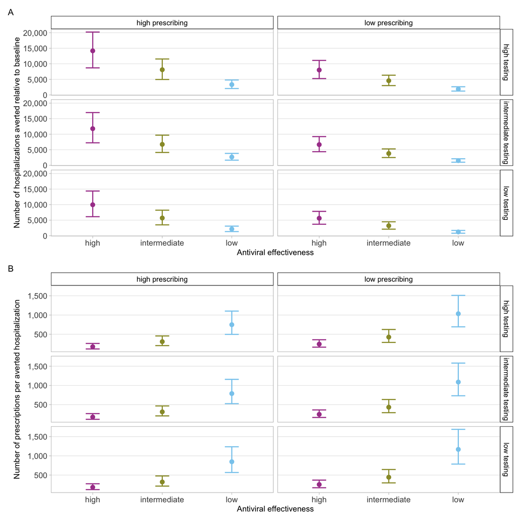

Partitioned by age and risk group:

Total hospitalizations averted

```
## # A tibble: 5 × 8
##   risk  age   testing      prescribing      effectiveness     mean  lower  upper
##   <chr> <fct> <chr>        <chr>            <chr>            <dbl>  <dbl>  <dbl>
## 1 high  0-4   high testing high prescribing high NAI effect   44.7   21.0 7.50e1
## 2 high  5-17  high testing high prescribing high NAI effect  104.    44.5 1.82e2
## 3 high  18-49 high testing high prescribing high NAI effect 1575.   849.  2.55e3
## 4 high  50-64 high testing high prescribing high NAI effect 2551.  1326.  4.16e3
## 5 high  65+   high testing high prescribing high NAI effect 8061.  2927.  1.42e4
```

```
## # A tibble: 5 × 8
##   risk  age   testing     prescribing     effectiveness     mean   lower  upper
##   <chr> <fct> <chr>       <chr>           <chr>            <dbl>   <dbl>  <dbl>
## 1 high  0-4   low testing low prescribing high NAI effect   15.4    7.25   25.5
## 2 high  5-17  low testing low prescribing high NAI effect   36.0   15.5    62.0
## 3 high  18-49 low testing low prescribing high NAI effect  543.   295.    866.
## 4 high  50-64 low testing low prescribing high NAI effect  890.   458.   1422.
## 5 high  65+   low testing low prescribing high NAI effect 2849.  1044.   4996.
```

```
## # A tibble: 5 × 8
##   risk  age   testing      prescribing      effectiveness    mean lower upper
##   <chr> <fct> <chr>        <chr>            <chr>           <dbl> <dbl> <dbl>
## 1 high  0-4   high testing high prescribing high NAI effect  2.59  1.87  3.43
## 2 high  5-17  high testing high prescribing high NAI effect  2.51  1.84  3.30
## 3 high  18-49 high testing high prescribing high NAI effect  3.48  2.53  4.64
## 4 high  50-64 high testing high prescribing high NAI effect  3.65  2.73  4.67
## 5 high  65+   high testing high prescribing high NAI effect  3.20  2.43  4.05
```

### Alternative scenarios: increased individual-level parameters

Increase parameters that represent

- Increased % seeking care
- Increased % of care-seekers doing so within 2d
- Increased antiviral compliance

Compare to baseline scenario, assuming NAI effectiveness is at its highest value.

Total averted

```
## # A tibble: 5 × 6
##   risk  age   alternative                              mean  lower  upper
##   <chr> <fct> <chr>                                   <dbl>  <dbl>  <dbl>
## 1 high  0-4   seek care, seek care early, and comply   137.   64.0   231.
## 2 high  5-17  seek care, seek care early, and comply   319.  137.    556.
## 3 high  18-49 seek care, seek care early, and comply  4815. 2598.   7845.
## 4 high  50-64 seek care, seek care early, and comply  7739. 3990.  12679.
## 5 high  65+   seek care, seek care early, and comply 24220. 8709.  42968.
```

Percent averted

```
## # A tibble: 5 × 6
##   risk  age   alternative                             mean lower upper
##   <chr> <fct> <chr>                                  <dbl> <dbl> <dbl>
## 1 high  0-4   seek care, seek care early, and comply  7.90  5.72  10.5
## 2 high  5-17  seek care, seek care early, and comply  7.68  5.64  10.1
## 3 high  18-49 seek care, seek care early, and comply 10.6   7.73  14.2
## 4 high  50-64 seek care, seek care early, and comply 11.1   8.24  14.3
## 5 high  65+   seek care, seek care early, and comply  9.60  7.24  12.3
```

### Alternative scenarios: increased clinical-level parameters

- Increased testing (regardless of timing)
- Increased prescribing among care-seekers with a positive test (regardless of timing)

Compare to best and worst-case scenarios, assuming NAI effectiveness is at its highest value.

Total averted

```
## # A tibble: 5 × 6
##   risk  age   alternative                mean  lower  upper
##   <chr> <fct> <chr>                     <dbl>  <dbl>  <dbl>
## 1 high  0-4   testing and prescribing    72.9   33.7   123.
## 2 high  5-17  testing and prescribing   170.    71.7   299.
## 3 high  18-49 testing and prescribing  2570.  1386.   4208.
## 4 high  50-64 testing and prescribing  4126.  2126.   6797.
## 5 high  65+   testing and prescribing 12909.  4650.  22834.
```

Percent averted

```
## # A tibble: 5 × 6
##   risk  age   alternative              mean lower upper
##   <chr> <fct> <chr>                   <dbl> <dbl> <dbl>
## 1 high  0-4   testing and prescribing  4.22  3.03  5.58
## 2 high  5-17  testing and prescribing  4.10  2.96  5.42
## 3 high  18-49 testing and prescribing  5.68  4.09  7.63
## 4 high  50-64 testing and prescribing  5.91  4.35  7.62
## 5 high  65+   testing and prescribing  5.12  3.83  6.59
```

### Alternative scenarios: everything

Total averted

```
## # A tibble: 5 × 6
##   risk  age   alternative                    mean  lower  upper
##   <chr> <chr> <chr>                         <dbl>  <dbl>  <dbl>
## 1 high  0-4   increase in all 5 parameters   229.   106.   390.
## 2 high  18-49 increase in all 5 parameters  8090.  4360. 13326.
## 3 high  5-17  increase in all 5 parameters   535.   225.   944.
## 4 high  50-64 increase in all 5 parameters 12909.  6673. 21320.
## 5 high  65+   increase in all 5 parameters 40093. 14332. 71087.
```

Percent averted

```
## # A tibble: 5 × 6
##   risk  age   alternative                   mean lower upper
##   <chr> <chr> <chr>                        <dbl> <dbl> <dbl>
## 1 high  0-4   increase in all 5 parameters  13.3  9.51  17.6
## 2 high  18-49 increase in all 5 parameters  17.9 12.8   24.0
## 3 high  5-17  increase in all 5 parameters  12.9  9.30  17.1
## 4 high  50-64 increase in all 5 parameters  18.5 13.5   24.0
## 5 high  65+   increase in all 5 parameters  15.9 11.8   20.6
```

Across all age groups and risk stratifications:

Total and percent averted

```
## # A tibble: 1 × 6
##   risk  age   alternative                    mean  lower   upper
##   <chr> <chr> <chr>                         <dbl>  <dbl>   <dbl>
## 1 all   all   increase in all 5 parameters 71142. 43581. 102969.
```

```
## # A tibble: 1 × 6
##   risk  age   alternative                   mean lower upper
##   <chr> <chr> <chr>                        <dbl> <dbl> <dbl>
## 1 all   all   increase in all 5 parameters  13.3  11.0  16.2
```

NNT

```
## # A tibble: 2 × 6
##   risk  age   alternative                   mean lower upper
##   <chr> <chr> <chr>                        <dbl> <dbl> <dbl>
## 1 all   all   increase in all 5 parameters  107.  71.1  157.
## 2 all   all   initial                       176. 117.   261.
```